# 5GT Cash-Flow Simulation

Ernesto

March 8, 2018

## Simulations

In the past month I’ve been trying to collect as much economic data as possible about the boats. The idea is to coalesce all the various sources of data, use them for some basic simulation and make sure the numbers that come out are reasonable.

If they are reasonable, we just take them and plug them into POSEIDON. If they are not reasonable we go back and figure out which data source is wrong.

First we can take all boats $\leq 6\text{ GT}$ and check on average how heavy their catches are.

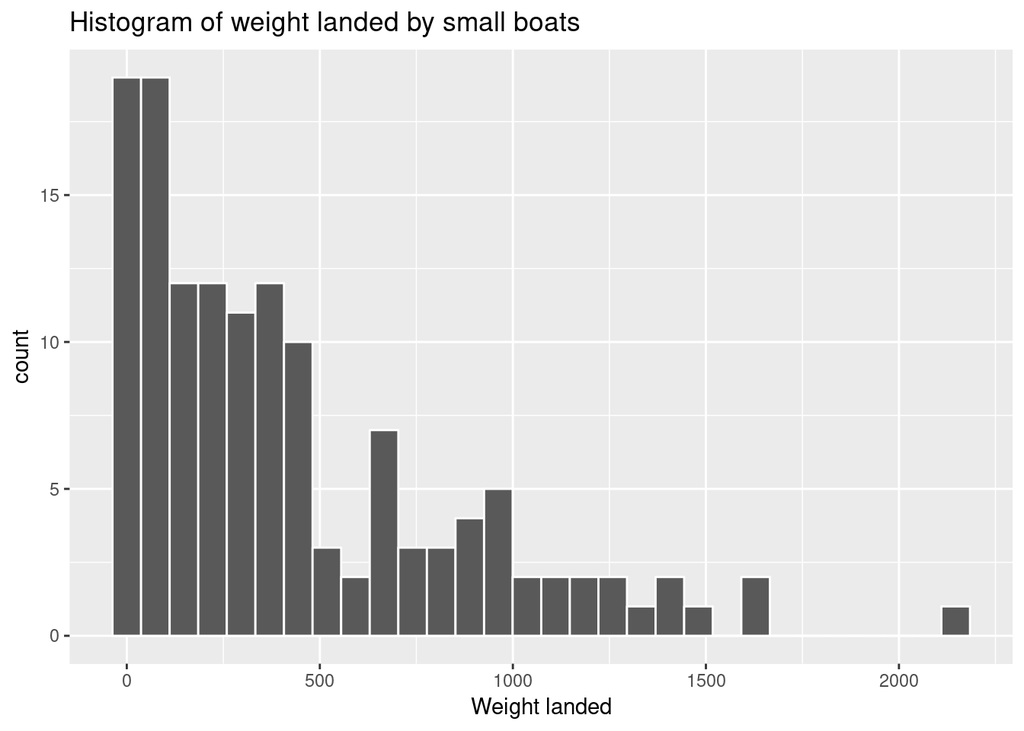

It is clear that boats in the WPP 573 consistently land more than others.

| wpp1 | weight | count |
| --- | --- | --- |
| 573 | 769.7822 | 59 |
| 712 | 342.2591 | 16 |
| 713 | 62.6862 | 34 |
| 718 | 200.2357 | 28 |

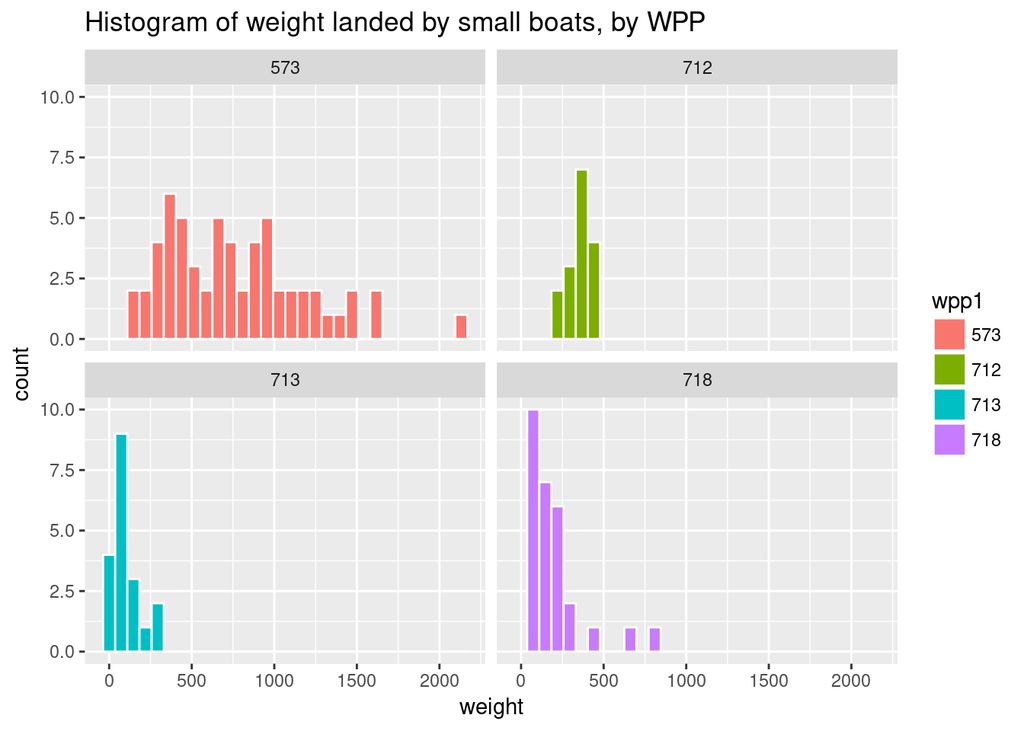

Even though landings are very heterogeneous in terms of species caught and each species have very different prices, on average the relationship between landings and earnings is very linear. Approximately each kg landed nets 40,000 IDR.

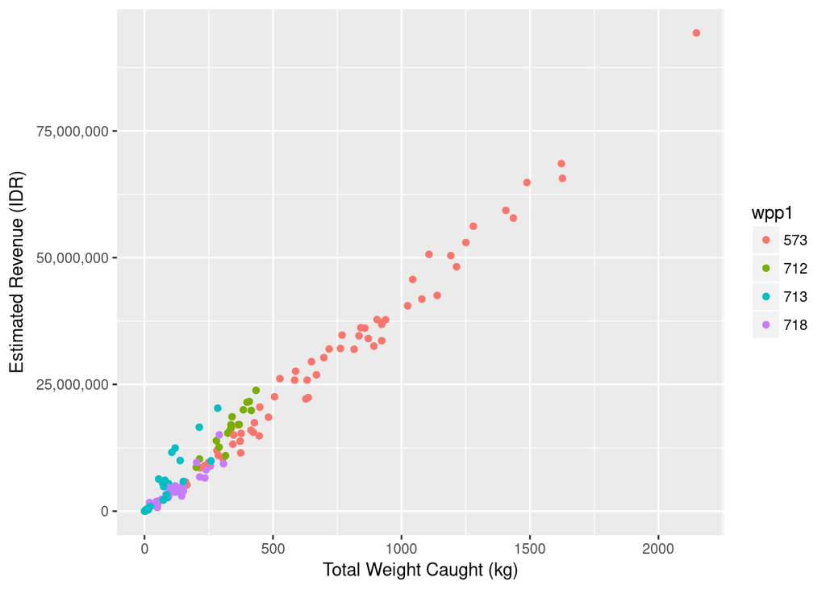

|  | Estimate | Std. Error | t value | Pr(>\|t\|) |
| --- | --- | --- | --- | --- |
| weight | 41904.4 | 364.939 | 114.8258 | 0 |

In order to simulate profits however we also need costs. Elle has been very helpful as a few of the receipts she photographed had cost information. For a few of those we could go back and extract the trip from the CODRS db. This was a pain but the code is available in the dropbox folder so we should be able to replicate it.

At the end of all that I come up with a table like this:

| Boat | Date | GT | Expenditures ($/hr) | Duration (hr) | Travel time (hr) | Km travelled | Profit/Expenditures |
| --- | --- | --- | --- | --- | --- | --- | --- |
| Cahaya 01 | 2017-10-23 | 7 | 28193.99 | 88.67139 | 32.138056 | 98.15202 | 1.1280000 |
| Arini 1 | 2017-11-06 | 5 | 43360.72 | 89.62028 | 39.880278 | 223.24351 | 0.5836336 |
| KM Duit | 2017-10-01 | 5 | 26722.54 | 99.69111 | 25.108333 | 221.39609 | 0.4076577 |
| KM Duit | 2017-10-28 | 5 | 62709.87 | 70.99361 | 4.975556 | 99.02354 | 0.6734052 |
| KM Duit | 2017-11-05 | 5 | 26684.64 | 93.53694 | 14.895556 | 159.72218 | 2.1274038 |
| Aulia Syam | 2017-10-13 | 10 | 16467.91 | 551.19306 | 134.229167 | 916.63197 | 3.2124050 |
| Aulia Syam | 2017-08-09 | 10 | 21875.82 | 531.50000 | 251.327222 | 1203.96819 | 1.2351423 |
| Millenium 4 | 2017-09-08 | 30 | 313206.28 | 352.26306 | 182.639444 | 1597.15126 | 0.1812727 |

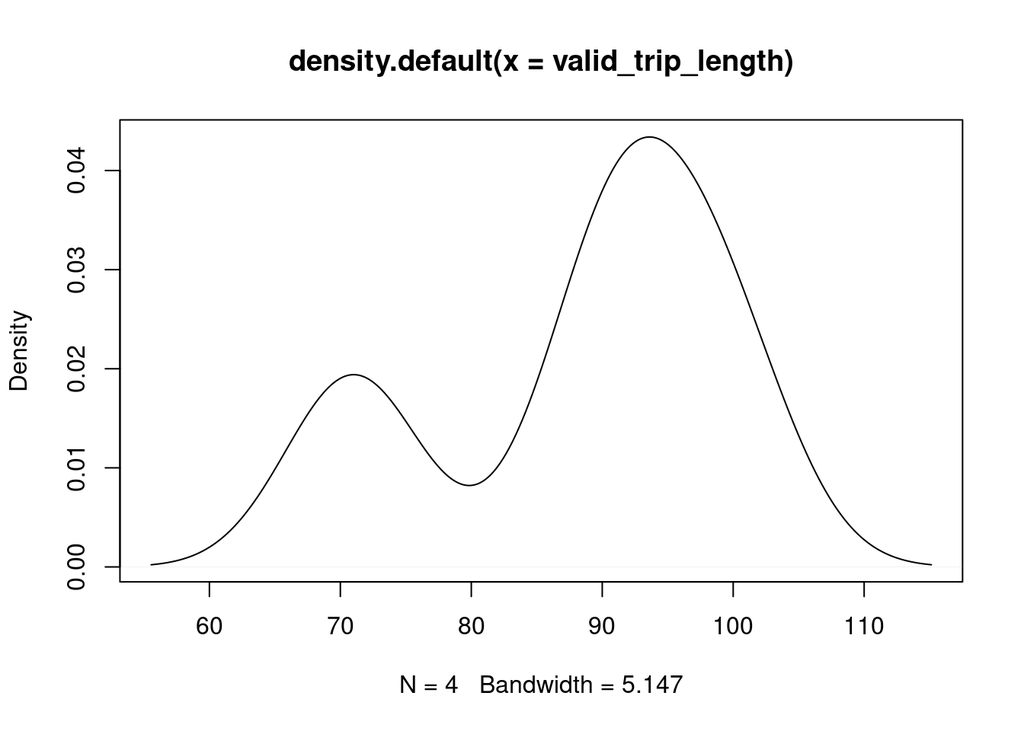

Now we can generate random trip profits at will.

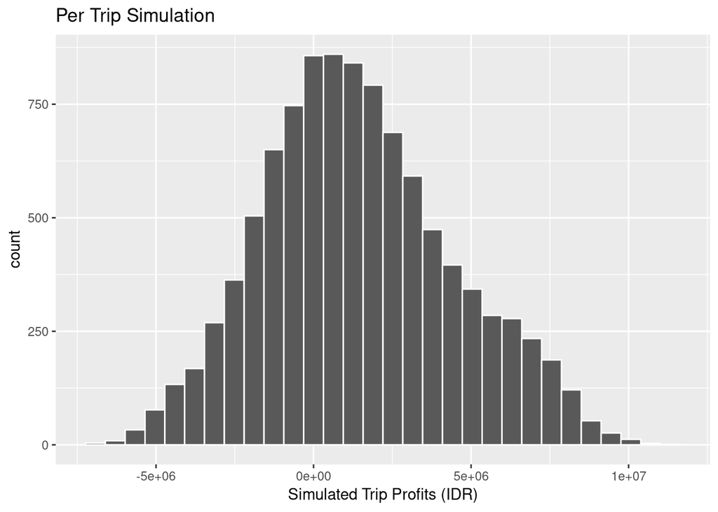

```
##     Min.  1st Qu.   Median     Mean  3rd Qu.     Max.
## -7237927  -693516  1189344  1435100  3358274 11016052
```

Now imagine that each year people make between 6 to 9 trips a year and we get

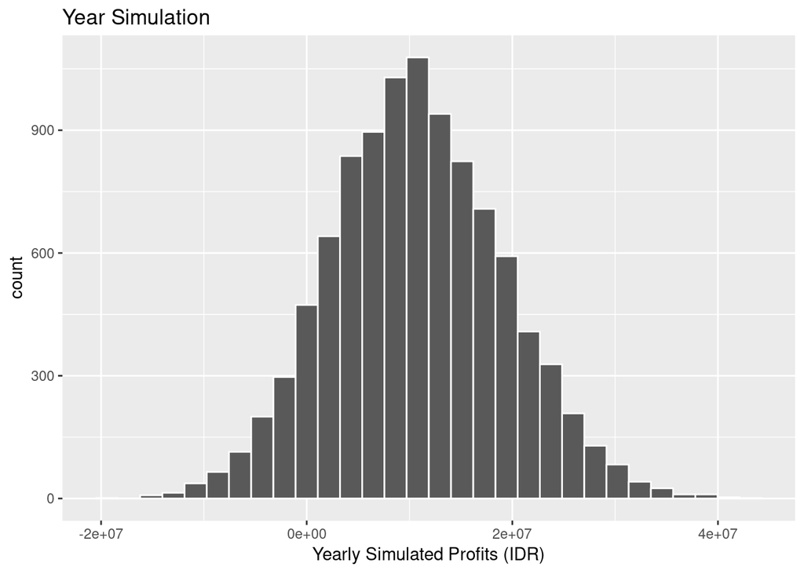

```
##      Min.   1st Qu.    Median      Mean   3rd Qu.      Max.
## -19362421   4920638  10460882  10742510  16314853  43277939
```

Then we have that on average a 5GT boat will make yearly profits of about 11M IDR. That’s quite low; if we assume that a 5GT boats costs 250M, its yearly upkeep will probably be about 50M.

## Things to validate this analysis

1. Do small boats (excluding wpp 573) make about
   - Average trip revenues of about 5M?
   - Average trip profits of about 1.5M?
   - Average yearly profits of about 10M?
   - Make a loss on average on 33.56% of the trips?
2. Is it true that:
   - Small boats on average earn less (through fishing) than the value of maintaining the boat?